# Assignment_1.3_HillZach

Zach Hill

September 1, 2019

## Importing Libraries

```r
knitr::opts_chunk$set(echo = TRUE)

library(tidyverse)
library(blscrapeR)
library(dplyr)
library(ggplot2)
library(grid)
library(gridExtra)
library(scales)
library(kableExtra)
```

## Loading Data

```r
url <- 'https://download.bls.gov/pub/time.series/ap/ap.data.3.Food'
data <- read.table(url, sep='\t', header = TRUE)
data$value <- as.numeric(levels(data$value))[data$value]

df1 <- spread(data, series_id, value)

cols <- c('year',
          'period',
          'date',
          Bread = 'APU0000702212    ',
          Beef = 'APU0000703111    ',
          Chicken = 'APU0000706111    ',
          Eggs = 'APU0000708111    ',
          Milk = 'APU0000709112    ',
          Cheese = 'APU0000710211    ',
          Apples = 'APU0000711111    ',
          Oranges = 'APU0000711311    ')

df2 <- dateCast(df1)
df <- select(df2, cols)

df_recent <- df %>% filter(dplyr::between(df$year, 2008, 2019))

write.csv(df, 'bls_ap_food.csv')
write.csv(df_recent, 'bls_ap_food_08-19.csv')
```

## Summary Statistics

### Bread

```r
summary(df_recent$Bread)
```

```
##    Min. 1st Qu.  Median    Mean 3rd Qu.    Max.
##   1.681   1.919   1.965   1.956   2.019   2.093
```

### Eggs

```r
mean(df_recent$Eggs, na.rm = TRUE)
```

```
## [1] 1.800292
```

```r
median(df_recent$Eggs, na.rm = TRUE)
```

```
## [1] 1.794
```

```r
sd(df_recent$Eggs, na.rm = TRUE)
```

```
## [1] 0.3249507
```

```r
quantile(df_recent$Eggs, probs = c(.25, .75), na.rm = TRUE)
```

```
##     25%     75%
## 1.55625 1.96050
```

## Plots

### Time-Series Plot

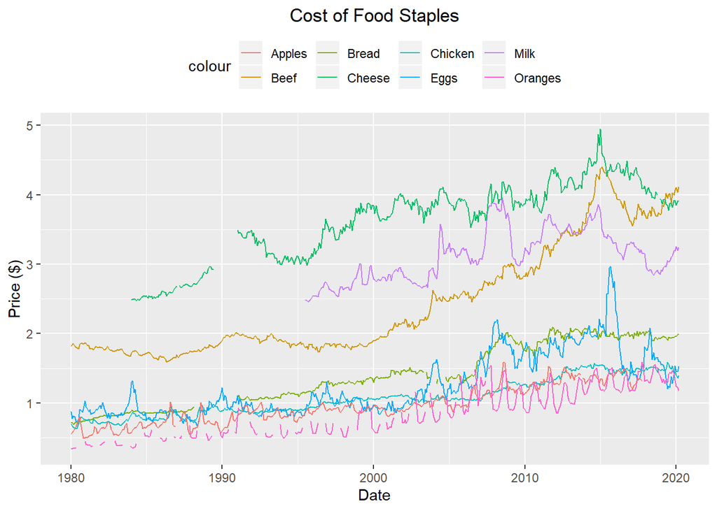

### Histogram and Boxplot

[figure not shown]

### Line with Linear Regression

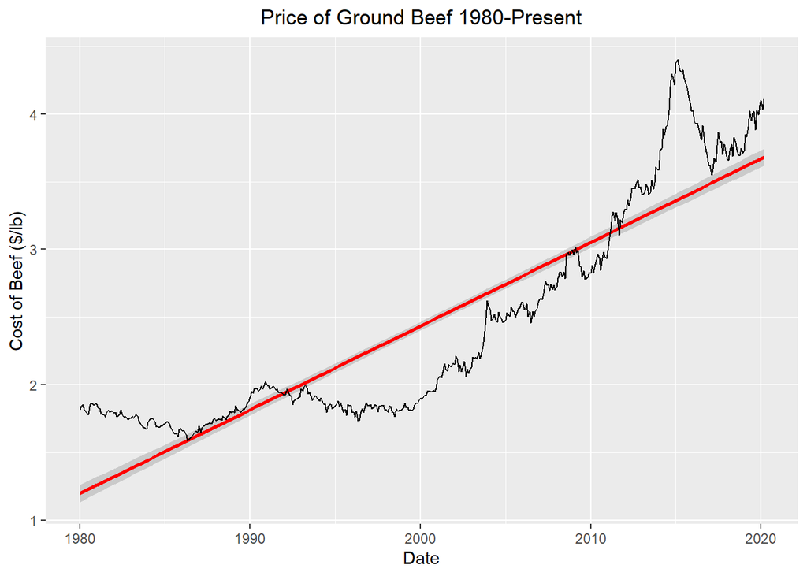

### Scatter Plot with Correlation and Linear Regression

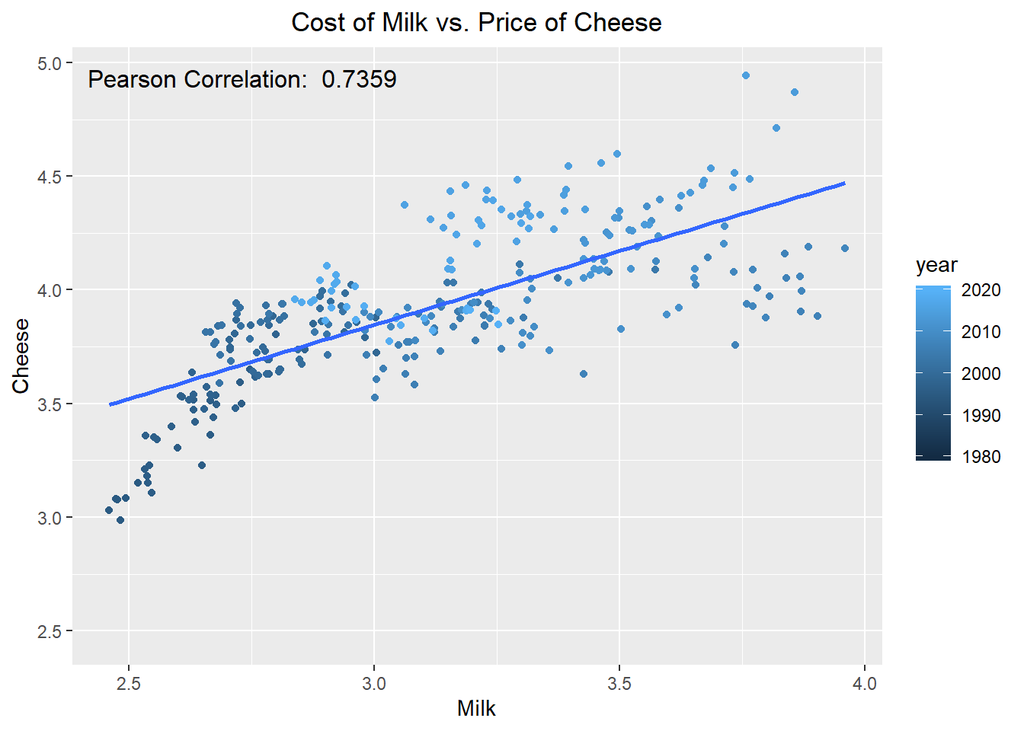

## Summary Report

### Dataframe Structure

```r
str(df)
```

```
## 'data.frame':    483 obs. of  11 variables:
##  $ year   : int  1980 1980 1980 1980 1980 1980 1980 1980 1980 1980 ...
##  $ period : Factor w/ 12 levels "M01","M02","M03",..: 1 2 3 4 5 6 7 8 9 10 ...
##  $ date   : Date, format: "1980-01-01" "1980-02-01" ...
##  $ Bread  : num  0.715 0.723 0.696 0.713 0.72 0.726 0.735 0.741 0.723 0.739 ...
##  $ Beef   : num  1.82 1.84 1.85 1.82 1.81 ...
##  $ Chicken: num  0.699 0.673 0.655 0.638 0.628 0.64 0.71 0.751 0.791 0.792 ...
##  $ Eggs   : num  0.879 0.774 0.812 0.797 0.737 0.731 0.776 0.907 0.898 0.867 ...
##  $ Milk   : num  NA NA NA NA NA NA NA NA NA NA ...
##  $ Cheese : num  NA NA NA NA NA NA NA NA NA NA ...
##  $ Apples : num  0.554 0.574 0.593 0.634 0.663 0.701 0.753 0.807 0.702 0.57 ...
##  $ Oranges: num  0.339 0.337 0.352 0.349 0.36 NA NA NA NA NA ...
```

### Data Summary

|  | Bread | Beef | Chicken | Eggs | Milk | Cheese | Apples | Oranges |
| --- | --- | --- | --- | --- | --- | --- | --- | --- |
| Min. | 0.6960 | 1.5890 | 0.6280 | 0.6780 | 2.4590 | 2.4720 | 0.4960 | 0.3370 |
| 1st Qu. | 1.0608 | 1.8160 | 0.8815 | 0.8975 | 2.8000 | 3.1720 | 0.7500 | 0.5710 |
| Median | 1.3570 | 1.9760 | 1.0390 | 1.0610 | 3.1050 | 3.8030 | 0.9185 | 0.8880 |
| Mean | 1.4143 | 2.4391 | 1.0711 | 1.2449 | 3.1154 | 3.6298 | 0.9580 | 0.9038 |
| 3rd Qu. | 1.9202 | 2.9585 | 1.2725 | 1.5555 | 3.3890 | 4.0115 | 1.1752 | 1.2180 |
| Max. | 2.0930 | 4.4030 | 1.5900 | 2.9660 | 3.9610 | 4.9440 | 1.5840 | 1.5900 |

## Reporting Findings

The cost of living increases over time. This is inevitable as markets grow, currencies change relative values and wages increase. Food staples, foods that almost all people eat and are used in most diets should be a good indicator of how the cost of living has increased over the years. The Bureau of Labor and Statistics has kept track of these items with faily good regularity since 1980. These reports investigate how those food staples’ prices have changed and prepares us to make predictions on how they will change in the future.

#### Bread

The average cost of a pound of whole wheat bread over the past 40 years is roughly $1.41 per pound. Currently whole wheat bread costs $1.95 per pound, an increase of $0.54 per pound over the mean. Since the recession, when prices tended to increase rapidly, however, the cost of bread has remained fairly flat with a difference of only $0.01 per pound relative to the mean over the past 11 years.

#### Milk and Cheese

The correlation between the prices of milk and cheese is not surprising, but it should not be considered causal either. With a value of 0.7359 however, it is a very strong correlation.

#### Apples and Oranges

I just wanted to compare Apples and Oranges. Orange price variability is largely seasonal and varied year over year where apples tend to remain more stable. The notable gaps in the early data for these staple fruits is caused by a lack of distribution methods which could keep the fruits fresh; methods which have since been remedied as evidenced by the more consistent pricing index.